# Mapa Mimulus - LG11

Cristiane Taniguti, Fernando Correr, Fernando Espolador, Johnathan Pedroso

Maio de 2017

Avaliação individual do grupo 11 formado a partir dos marcadores contidos [neste arquivo](https://cristianetaniguti.github.io/htmls/mapa_mimulus/data_with_head.raw). Para mais informações acesse a [página principal](https://cristianetaniguti.github.io/htmls/mapa_mimulus/mapa_mimulus.html).

# 1 Carregando dados gerados na pagina principal

```r
load("LGs_force_HMM_Markers_First_Check.RData")
load("LGs_safe_HMM_Markers_First_Check.RData")


library(onemap)
data1 <- read_mapmaker(file = "data_with_head.raw")
LOD <- suggest_lod(data1)
rf2points <- rf_2pts(data1, LOD = LOD, max.rf = 0.5)
```

# 2 Breve comparação com o mapa publicado

Desde já podemos comparar os grupos formados com o mapa já publicado, para sabermos a correspondência entre ambos. Para facilitar, fizemos [esta tabela](https://cristianetaniguti.github.io/htmls/mapa_mimulus/LG.csv) com os nomes dos marcadores que compoem o mapa publicado, sendo que cada coluna da tabela corresponde à um grupo de ligação.

```r
ref <- read.csv(file = "LG.csv", stringsAsFactors = FALSE)
names <- colnames(data1$geno)[LGs.HMM.force[[11]]$seq.num]

comp <- pos <- lgs <- pos2 <- num_lgs <- list()
for (i in 1:length(ref)){
  comp[[i]] <- ref[[i]] %in% names
  pos[[i]] <- which(comp[[i]] == TRUE)
  lgs[[i]] <- ref[[i]][pos[[i]]]
  pos2[[i]] <- names %in% lgs[[i]]
  num_lgs[[i]] <- LGs.HMM.force[[1]]$seq.num[pos2[[i]]]
}

comp
```

[output not shown]

# 3 Comparando “safe” e “force”

Para este grupo foi verificada certa correspondência com o grupo de ligação 12 do mapa anterior, já que grande parte dos marcadores estavam nesse grupo. Vale ressaltar que não foram encontrados os marcadores desse grupo em outros grupos de ligação da outra publicação.

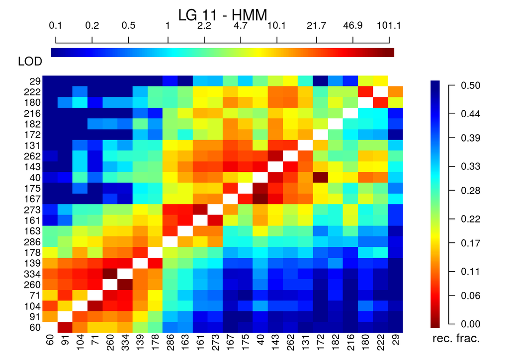

```r
# Identificando marcadores presentes no "force" e ausentes no "safe" de HMM
comp_unsafe <- LGs.HMM.force[[11]]$seq.num %in% LGs.HMM.safe[[11]]$seq.num
pos_unsafe <- which(comp_unsafe == FALSE)
unsafe <- LGs.HMM.force[[11]]$seq.num[pos_unsafe]
unsafe

#O safe também não retirou nenhum dos marcadores. Dessa maneira, ele foi mantido desta maneira para análises posteriores.

#Fazendo o gráfico para este grupo analisado
LG11.ord.seq <- LGs.HMM.force[[11]]

rf_graph_table(LG11.ord.seq, scale = 2.2, main = paste("LG", 11, "- HMM"), inter = FALSE)
```

# 4 Removendo marcadores duvidosos

Conforme heatmap gerado pela cadeia de markov e as sugestões do comando “safe”, removemos alguns marcadores duvidosos do mapa na intenção de aprimorar o ordenamento.

A partir do heatmap do grupo de ligação 11, tomou-se a decisão de retirar os marcadores 216 e 180. Em uma segunda rodada de avaliação, verificou-se que também seria interessante retirar os marcadores 182, 172 e 175.

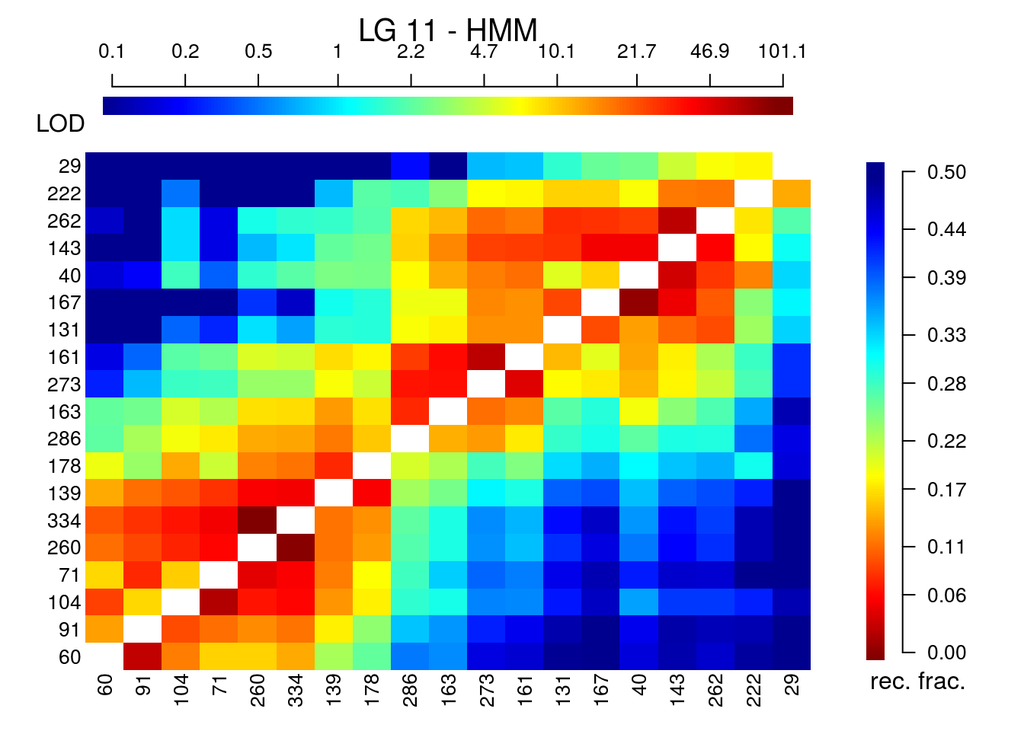

```r
Temp <- c(216, 180, 182, 172, 175)

Exc <- LGs.HMM.force[[11]]$seq.num %in% Temp

pos <- which(Exc == TRUE)

LG11.Exc <- LGs.HMM.force[[11]]$seq.num[-pos]

length(LG11.Exc)

LG11 <- make_seq(rf2points, LG11.Exc)

LG11

LG11.ord <- order_seq(LG11, n.init = 5, THRES = 3,
                      touchdown = TRUE, draw.try = FALSE)


LG11.ord.seq <- make_seq(LG11.ord, "force")


rf_graph_table(LG11.ord.seq, scale = 2.2, main = paste("LG", 11, "- HMM"),
               inter = FALSE)
```

```r
save(LG11.ord.seq, file = "LG11.Rdata")
```